# Models of vegetation composition based on climate predictors

Based on code from Martin Holdrege’s Sagebrush-Fire paper

Alice Stears

2024-07-21

The data consists of vegetation % cover by functional group from across CONUS (from AIM, FIA, LANDFIRE, and RAP), as well as climate variables from DayMet, which have been aggregated into mean interannual conditions accross multiple temporal windows.

# Dependencies

User defined parameters

```r
print(params)
```

```
## $test_run
## [1] TRUE
##
## $save_figs
## [1] FALSE
##
## $response
## [1] "HerbCover_dec"
##
## $hmod
## [1] FALSE
##
## $s
## [1] "HerbCover"
```

```r
# set to true if want to run for a limited number of rows (i.e. for code testing)
test_run <- params$test_run
save_figs <- params$save_figs
hmod <- params$hmod # whether to include human modification in the model
# by changing the sample_group the model can be fit to a completely different set of rows
sample_group <- params$sample_group
response <- params$response
# _ann defines this model as being built on annual data
s <- params$s # string to paste to file names e.g., that defines the interactions in the model
# such as (summer ppt * MAT) and annuals*temperature interactions
fit_sample <- TRUE # fit model to a sample of the data
n_train <- 5e6 # sample size of the training data
n_test <- 1e6 # sample size of the testing data (if this is too big the decile dotplot code throws memory errors)
```

```r
# set option so resampled dataset created here reproduces earlier runs of this code with dplyr 1.0.10
source("../../Functions/glmTransformsIterates.R")
source("../../Functions/transformPreds.R")
#source("src/fig_params.R")
#source("src/modeling_functions.R")

library(betareg)
library(tidyverse)
library(GGally) # for ggpairs()
library(pdp) # for partial dependence plots
library(gridExtra)
library(knitr)
library(patchwork) # for figure insets etc.
library(ggtext)
theme_set(theme_classic())
```

# read in data

Data compiled in the `prepDataForModels.R` script

```r
modDat <- readRDS("../../data/DataForModels.rds")
```

# Prep data

```r
set.seed(1)
modDat_1 <- modDat

# small dataset for if testing the data
if(test_run) {
  modDat_1 <- slice_sample(modDat_1, n = 1e5)
}
```

For now, not doing any resampling

```r
set.seed(1234)

pred_vars <- c("swe_meanAnnAvg_5yr", "tmin_meanAnnAvg_5yr", "prcp_meanAnnTotal_5yr",    "precip_Seasonality_meanAnnAvg_5yr", "PrecipTempCorr_meanAnnAvg_5yr")

names(pred_vars) <- pred_vars

# predictor vars are the same in both dfs

## remove rows for data that have NAs in the predictors (lag starts before range of DayMet data)

modDat_1 <- modDat_1 %>%
  filter(!is.na(swe_meanAnnAvg_5yr) &
           !is.na(tmin_meanAnnAvg_5yr) &
           !is.na(prcp_meanAnnTotal_5yr) &
           !is.na(precip_Seasonality_meanAnnAvg_5yr) &
           !is.na(PrecipTempCorr_meanAnnAvg_5yr) &
           !is.na(paste(response)))

df_pred <- modDat_1[, pred_vars]
```

Training data

```r
df_sample <- if(fit_sample & !test_run) {
  reordered <- slice_sample(modDat_1, prop = 1)

  low <- (sample_group - 1)*n_train + 1 # first row (of reordered data) to get
  high <- low + n_train - 1 # last row
  if(high > nrow(modDat_1)) {
    stop('trying to sample from rows that dont exist')
  }
  reordered[low:high, ]
} else {
    modDat_1
}

df_test <- if(fit_sample & !test_run &
              # antijoin only works if there are enough rows that meet
              # that criterion, i.e. if df_sample contains most of the data i
              # doesnt' work
              (nrow(modDat_1) - nrow(df_sample) > n_test)) {
  modDat_1 %>%
    anti_join(df_sample, by = c("cell_num", "year")) %>%
    slice_sample(n = n_test)
} else {
  modDat_1 %>%
    slice_sample(n = n_test)
}

# small sample for certain plots
df_small <- slice_sample(modDat_1, n = 1e5)
```

# Exploratory figs & summary values

```r
create_summary <- function(df) {
  df %>%
    pivot_longer(cols = everything(),
                 names_to = 'variable') %>%
    group_by(variable) %>%
    summarise(across(value, .fns = list(mean = ~mean(.x, na.rm = TRUE), min = ~min(.x, na.rm = TRUE),
                                        median = ~median(.x, na.rm = TRUE), max = ~max(.x, na.rm = TRUE)))) %>%
    mutate(across(where(is.numeric), round, 4))
}

modDat_1[pred_vars] %>%
  create_summary() %>%
  knitr::kable(caption = 'summaries of predictor variables')
```

summaries of predictor variables

| variable | value_mean | value_min | value_median | value_max |
| --- | --- | --- | --- | --- |
| PrecipTempCorr_meanAnnAvg_5yr | -0.1267 | -0.9203 | -0.1049 | 0.8074 |
| prcp_meanAnnTotal_5yr | 754.7510 | 38.8317 | 547.2467 | 4927.2851 |
| precip_Seasonality_meanAnnAvg_5yr | 0.8670 | 0.3008 | 0.8362 | 2.5712 |
| swe_meanAnnAvg_5yr | 15.6472 | 0.0000 | 1.8763 | 2037.7961 |
| tmin_meanAnnAvg_5yr | 3.8923 | -10.8901 | 2.5786 | 22.6586 |

```r
response_summary <- modDat_1 %>%
    dplyr::select(#where(is.numeric), -all_of(pred_vars),
      matches(response)) %>%
    create_summary()


kable(response_summary,
      caption = 'summaries of response variables, calculated using paint')
```

summaries of response variables, calculated using paint

| variable | value_mean | value_min | value_median | value_max |
| --- | --- | --- | --- | --- |
| HerbCover_dec | 0.2076 | 1e-04 | 0.1 | 0.999 |

## Plot predictor vars against each other

here using pred dataframe, because smaller and this code is slow.

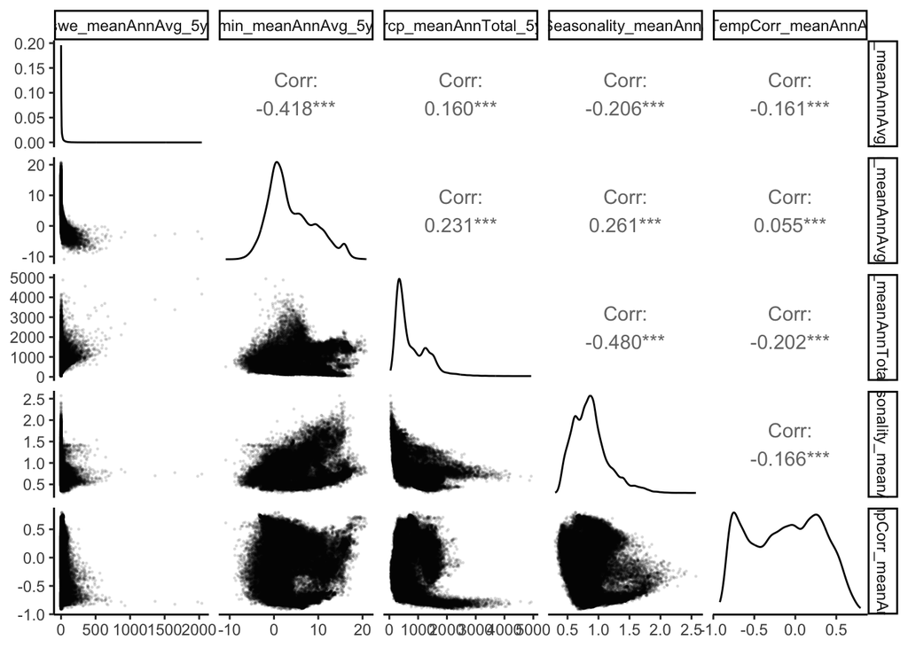

```r
df_pred %>%
  slice_sample(n = 5e4) %>%
  #select(-matches("_")) %>%
ggpairs(lower = list(continuous = GGally::wrap("points", alpha = 0.1, size=0.2)))
```

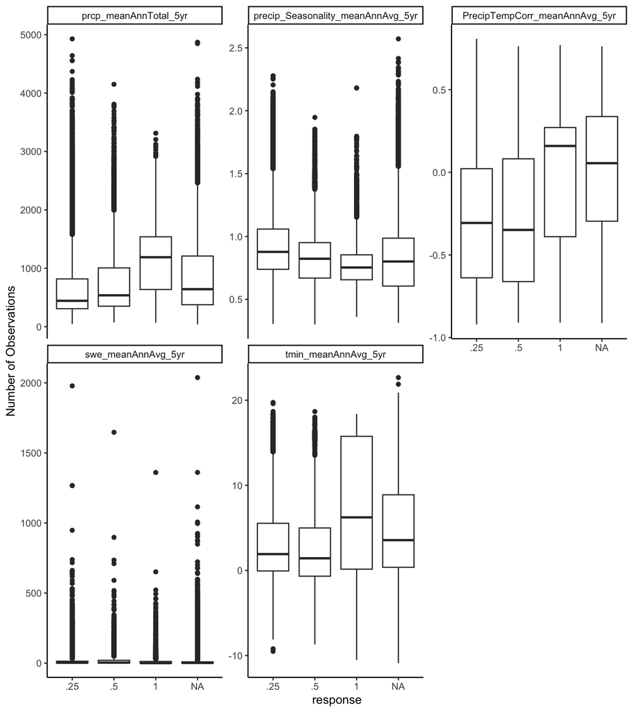

```r
# vectors of names of response variables
vars_response <- response

# longformat dataframes for making boxplots
df_sample_plots <-  df_sample %>%
  rename(response = all_of(response)) %>%
  mutate(response = case_when(
    response <= .25 ~ ".25",
    response > .25 & response <=.5 ~ ".5",
    response > 5 & response <=.75 ~ ".75",
    response >= .75  ~ "1",
  )) %>%
  select(c(response, pred_vars)) %>%
  pivot_longer(cols = swe_meanAnnAvg_5yr:PrecipTempCorr_meanAnnAvg_5yr,
               names_to = "predictor",
               values_to = "value")
# df_biome_long <-
#   # for some reason select() was giving me problems
#   # adding numYrs here so can take weighted average
#   predvars2long(modDat_1, response_vars = c(vars_response),
#                 pred_vars = pred_vars) #%>%
#    # mutate(across(all_of(vars_nfire), factor))


ggplot(df_sample_plots, aes_string(x= "response", y = 'value')) +
  geom_boxplot() +
  facet_wrap(~predictor, scales = 'free_y') +
  ylab("Number of Observations")
```

# GLMs

## fitting models

### fitting various transforms

Creating formulas where each variable on its own is transformed numerous ways (including formula to fit spline), all other variables are left alone, that repeated for each variable. So have models with 1 variable transformed, 2 transformed, etc.

see documentation for glms_iterate_transforms, in the modelling_functions.R script

```r
set.seed(1234)

# adding an interaction term to help deal with over-predicting fire probability
# at pixels with high afgAGB and high MAP. parentheses around interaction
# term are included so that glms_iterate_transforms doesn't transform
# the interaction term.
pred_vars_inter <- c(pred_vars, params$inter)


# pred_vars_inter <- pred_vars

mods_glm_cwf1 <- glmTransformsIterates(
  preds = pred_vars_inter,
  df = df_sample,
  response_var = response,
  delta_aic = 10)
```

```
## [1] "step1"
##
##  -82960.89
## -85347.41
## delta aic cutoff 10
## [1] "step2"
##
##  -85347.41
## -85997.37
## delta aic cutoff 10
## [1] "step3"
##
##  -85997.37
## -86271.39
## delta aic cutoff 10
## [1] "step4"
##
##  -86271.39
## -86379.26
## delta aic cutoff 10
## [1] "step5"
##
##  -86379.26
## -86412.67
## delta aic cutoff 10
```

```r
# not including the last element of the list which is final_formula
mods_glm_cwf2 <- mods_glm_cwf1[-length(mods_glm_cwf1)]

map_dfc(mods_glm_cwf2, ~ names(.$aic[1:5])) %>%
  kable(caption = "5 best transformations at each step")
```

5 best transformations at each step

| step1 | step2 | step3 | step4 | step5 |
| --- | --- | --- | --- | --- |
| convert_poly2_tmin_meanAnnAvg_5yr | convert_poly2_PrecipTempCorr_meanAnnAvg_5yr | convert_poly2log10_prcp_meanAnnTotal_5yr | convert_poly2sqrt_swe_meanAnnAvg_5yr | convert_poly2log10_precip_Seasonality_meanAnnAvg_5yr |
| convert_poly2sqrt_prcp_meanAnnTotal_5yr | convert_poly2log10_prcp_meanAnnTotal_5yr | convert_poly2sqrt_prcp_meanAnnTotal_5yr | convert_poly2log10_swe_meanAnnAvg_5yr | convert_poly2sqrt_precip_Seasonality_meanAnnAvg_5yr |
| convert_poly2log10_prcp_meanAnnTotal_5yr | convert_log10_prcp_meanAnnTotal_5yr | convert_log10_prcp_meanAnnTotal_5yr | convert_log10_swe_meanAnnAvg_5yr | convert_poly2_precip_Seasonality_meanAnnAvg_5yr |
| convert_log10_prcp_meanAnnTotal_5yr | convert_poly2sqrt_prcp_meanAnnTotal_5yr | convert_poly2_prcp_meanAnnTotal_5yr | convert_sqrt_swe_meanAnnAvg_5yr | convert_none |
| convert_poly2_prcp_meanAnnTotal_5yr | convert_poly2_prcp_meanAnnTotal_5yr | convert_poly2log10_precip_Seasonality_meanAnnAvg_5yr | convert_poly2log10_precip_Seasonality_meanAnnAvg_5yr | convert_log10_precip_Seasonality_meanAnnAvg_5yr |

```r
best_aic_by_step <- map_dbl(mods_glm_cwf2, ~.$aic[1])

best_aic_by_step <- c(step0 = mods_glm_cwf1$step1$aic[['convert_none']],
                      best_aic_by_step)
# AIC improvement by step
diff(best_aic_by_step)
```

```
##       step1       step2       step3       step4       step5
## -2386.51821  -649.96468  -274.01977  -107.86431   -33.41557
```

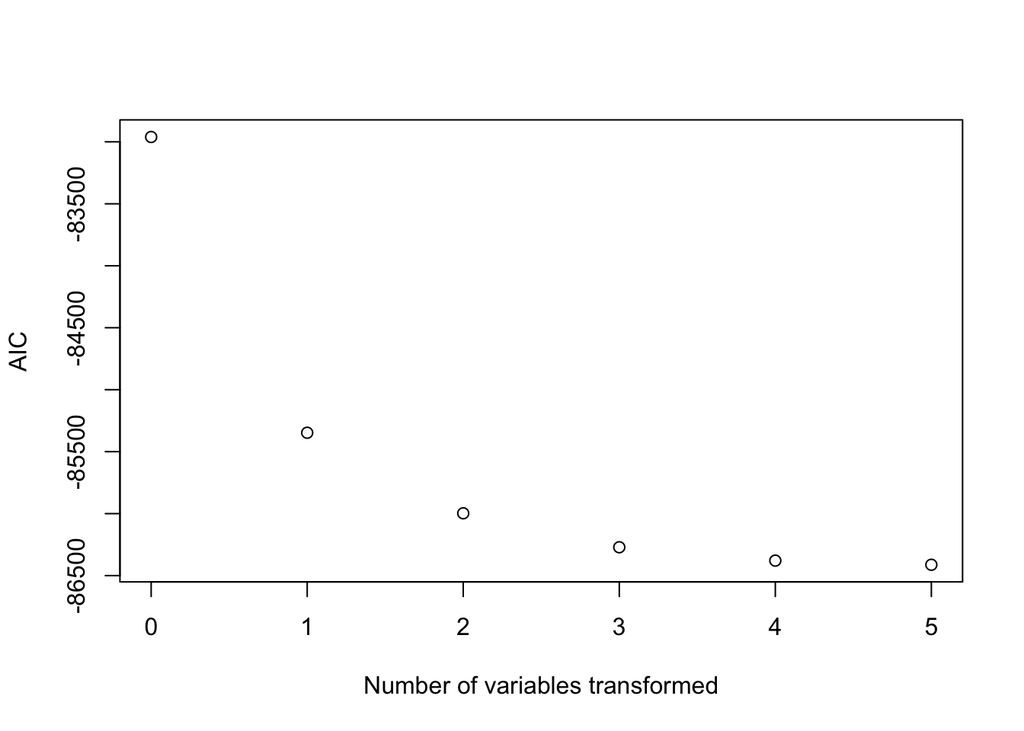

```r
plot(y = best_aic_by_step,
     x = 1:length(best_aic_by_step) - 1,
     ylab = "AIC",
     xlab = "Number of variables transformed")
```

Best transformation each step.

```r
var_transformed <- map(mods_glm_cwf2, function(x) x$var_transformed)
var_transformed
```

```
## $step1
## [1] "stats::poly(tmin_meanAnnAvg_5yr,2,raw=TRUE)"
##
## $step2
## [1] "stats::poly(PrecipTempCorr_meanAnnAvg_5yr,2,raw=TRUE)"
##
## $step3
## [1] "stats::poly(I(log10(I(prcp_meanAnnTotal_5yr+1))),2,raw=TRUE)"
##
## $step4
## [1] "stats::poly(I(sqrt(swe_meanAnnAvg_5yr)),2,raw=TRUE)"
##
## $step5
## [1] "stats::poly(I(log10(I(precip_Seasonality_meanAnnAvg_5yr+1))),2,raw=TRUE)"
```

### same model for all response variables

```r
best_form <- mods_glm_cwf1$final_formula
print(best_form)
```

```
##                                                                                                                                                                                                                                                                     convert_poly2log10_precip_Seasonality…
## "HerbCover_dec ~ stats::poly(I(sqrt(swe_meanAnnAvg_5yr)),2,raw=TRUE) + stats::poly(tmin_meanAnnAvg_5yr,2,raw=TRUE) + stats::poly(I(log10(I(prcp_meanAnnTotal_5yr+1))),2,raw=TRUE) + stats::poly(I(log10(I(precip_Seasonality_meanAnnAvg_5yr+1))),2, raw = TRUE) + stats::poly(PrecipTempCorr_meanAnnAvg_5…
```

```r
# refitting the glm with the best formula
mod_glm1 <- betareg(as.formula(best_form), data = df_sample, link = c("logit"), link.phi = NULL,
                              type = c("ML"))

# should be the same AIC (i.e. refitting the same model)
AIC(mod_glm1)
```

```
## [1] -86412.67
```

```r
#summary(mod_glm1)
```

## partial dependence & VIP

```r
# vip::vip(bin_glm1) # variable importance
#car::vif(mod_glm1)
#vip::vip(mod_glm1, num_features = 15)

#pdp_all_vars(mod_glm1, mod_vars = pred_vars, ylab = 'probability',train = df_small)
```

## observed vs. predicted

Predicting on the data

```r
# create prediction for each each model
# (i.e. for each fire proporation variable)
predict_by_response <- function(mod, df) {
  df_out <- df

  response_name <- paste0(response, "_pred")
  df_out[[response_name]] <- predict(mod, df, type = 'response')
  df_out
}

pred_glm1 <- predict_by_response(mod_glm1, df_test)
```

### Deciles

Binning predictor variables into deciles (actually percentiles) and looking at the mean predicted probability for each percentile. The use of the word deciles is just a legacy thing (they started out being actual deciles)

```r
var_prop_pred <- paste0(response, "_pred")
response_vars <- c(response, var_prop_pred)

pred_glm1_deciles <- predvars2deciles(pred_glm1,
                                      response_vars = response_vars,
                                      pred_vars = pred_vars)
```

Publication quality quantile plot

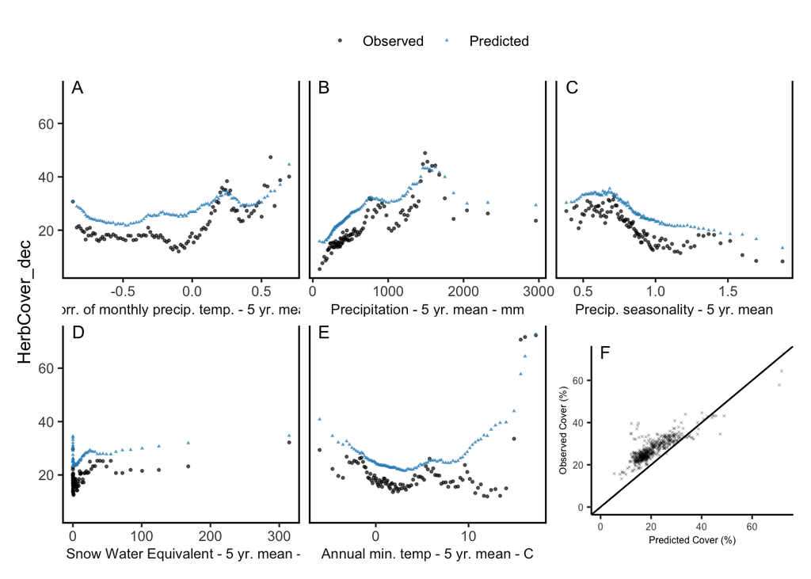

```r
# publication quality version
g <- decile_dotplot_pq(pred_glm1_deciles, response = response)

if(!hmod) {
# obs/pred inset
g2 <- add_dotplot_inset(g, pred_glm1_deciles)
} else {
  g2 <- g
}
g2
```

```r
if(save_figs) {
  png(paste0("figures/quantile_plots/quantile_plot_v5", s,  ".png"),
     units = "in", res = 600, width = 5.5, height = 3.5 )
    print(g2)
  dev.off()
}
```

### Deciles Filtered

20th and 80th percentiles for each climate variable

```r
df <- pred_glm1[, c("swe_meanAnnAvg_5yr", "tmin_meanAnnAvg_5yr", "prcp_meanAnnTotal_5yr", "precip_Seasonality_meanAnnAvg_5yr", "PrecipTempCorr_meanAnnAvg_5yr" )] #%>%
  #mutate(MAT = MAT - 273.15) # k to c
map(df, quantile, probs = c(0.2, 0.8), na.rm = TRUE)
```

```
## $swe_meanAnnAvg_5yr
##         20%         80%
##  0.01390411 17.38978916
##
## $tmin_meanAnnAvg_5yr
##        20%        80%
## -0.4040931  8.7231873
##
## $prcp_meanAnnTotal_5yr
##      20%      80%
##  313.210 1247.692
##
## $precip_Seasonality_meanAnnAvg_5yr
##       20%       80%
## 0.6183025 1.0611830
##
## $PrecipTempCorr_meanAnnAvg_5yr
##        20%        80%
## -0.5969731  0.2921237
```

Filtered ‘Decile’ plots of data. These plots show each vegetation variable, but only based on data that falls into the upper and lower two deciles of each climate variable.

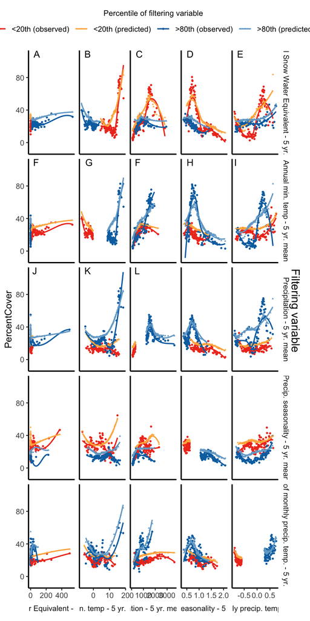

```r
clim_vars <- c("swe_meanAnnAvg_5yr", "tmin_meanAnnAvg_5yr", "prcp_meanAnnTotal_5yr", "precip_Seasonality_meanAnnAvg_5yr", "PrecipTempCorr_meanAnnAvg_5yr")
pred_glm1_deciles_filt <- predvars2deciles( pred_glm1,
                         response_vars = response_vars,
                         pred_vars = pred_vars,
                         filter_var = TRUE,
                         filter_vars = pred_vars)

decile_dotplot_filtered_pq(pred_glm1_deciles_filt, xvars = clim_vars)
```

```r
#decile_dotplot_filtered_pq(pred_glm1_deciles_filt)
```

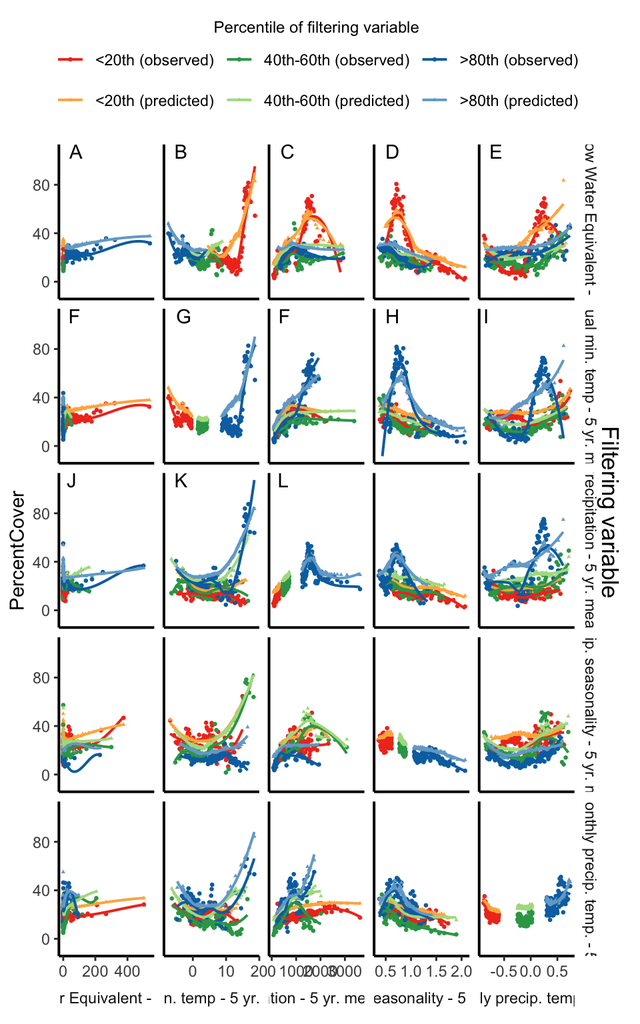

```r
pred_glm1_deciles_filt_mid <- predvars2deciles(pred_glm1,
                         response_vars = response_vars,
                         pred_vars = pred_vars,
                         filter_var = TRUE,
                         add_mid = TRUE)

g <- decile_dotplot_filtered_pq(df = pred_glm1_deciles_filt_mid)
g
```

```r
if(save_figs) {
jpeg(paste0("figures/quantile_plots/quantile_plot_filtered_mid_v1", s, ".jpeg"),
     units = "in", res = 600, width = 5.5, height = 6 )
  g
dev.off()
}
```

# Save output

```r
# glm models
mods2save <- butcher::butcher(mod_glm1) # removes some model components so the saved object isn't huge

mods2save$formula <- best_form
mods2save$pred_vars_inter <- pred_vars_inter # so have interactions
n <- nrow(df_sample)
mods2save$data_rows <- n

if(!test_run) {
  saveRDS(mods2save,
        paste0("models/glm_binomial_models_v3", s, "_", n, "n_g",
        sample_group, ".RDS"))
}
```

# session info

Hash of current commit (i.e. to ID the version of the code used)

```r
system("git rev-parse HEAD", intern=TRUE)
```

```
## [1] "b5a48e7ac013deaccffa1fb18f614185e98aee18"
```